# Malathion - Quality Control and GWAS

### 6.7 Pvalue distribution

Linear

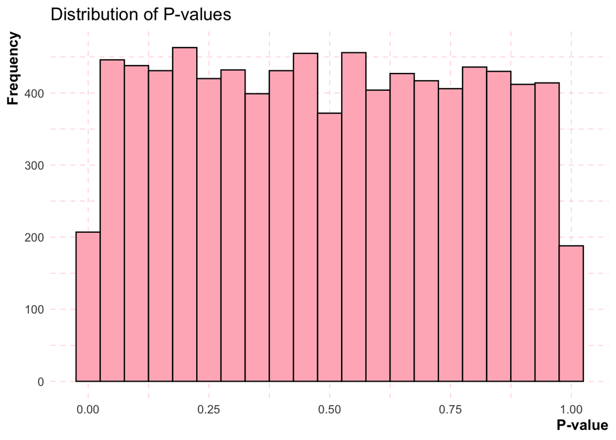

```r
# Create a histogram of p-values
ggplot(linear, aes(x = P)) +
  geom_histogram(binwidth = 0.05, color = "black", fill = "lightpink") +  # Adjust binwidth as needed
  labs(x = "P-value",
       y = "Frequency",
       title = "Distribution of P-values") +
  my_theme()
```

Logistic

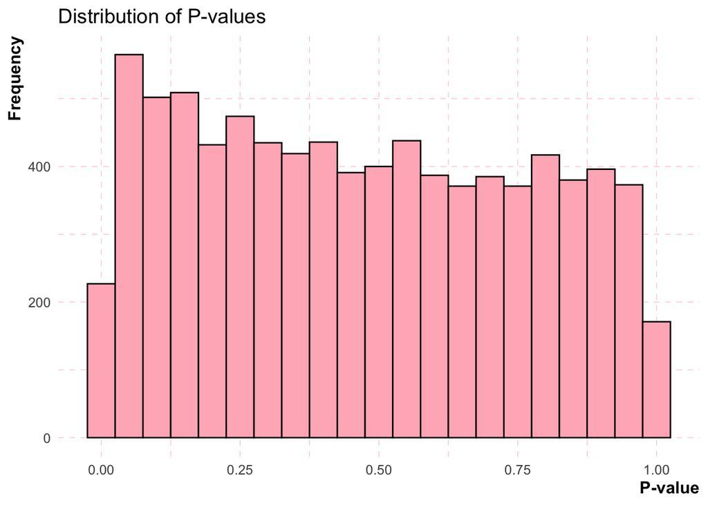

```r
# Create a histogram of p-values
ggplot(logistic, aes(x = P)) +
  geom_histogram(binwidth = 0.05, color = "black", fill = "lightpink") +  # Adjust binwidth as needed
  labs(x = "P-value",
       y = "Frequency",
       title = "Distribution of P-values") +
  my_theme()
```

### 6.8 Empirical cumulative distribution function (ECDF)

The empirical cumulative distribution function (ECDF) to visually compare our p-value distribution with the uniform distribution. If the ECDF of our p-values departs significantly from the diagonal, it suggests that our p-values are not uniformly distributed.

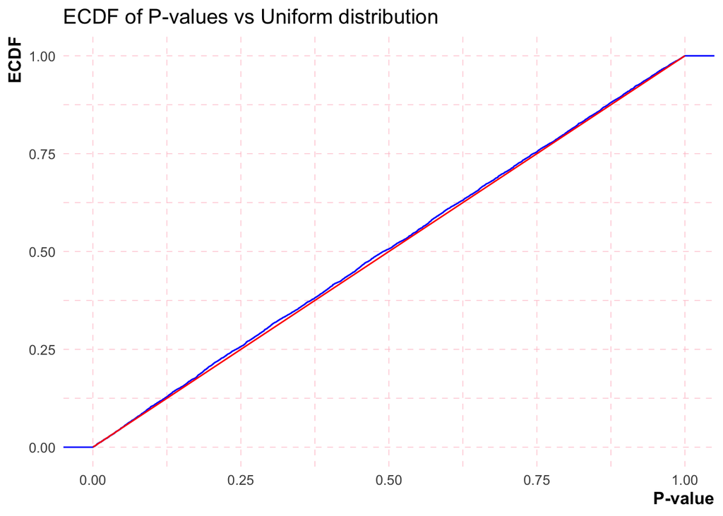

```r
ggplot(linear, aes(x = P)) +
  stat_ecdf(geom = "step", color = "blue") +
  stat_function(fun = punif, color = "red") +
  labs(x = "P-value",
       y = "ECDF",
       title = "ECDF of P-values vs Uniform distribution") +
  my_theme()
```

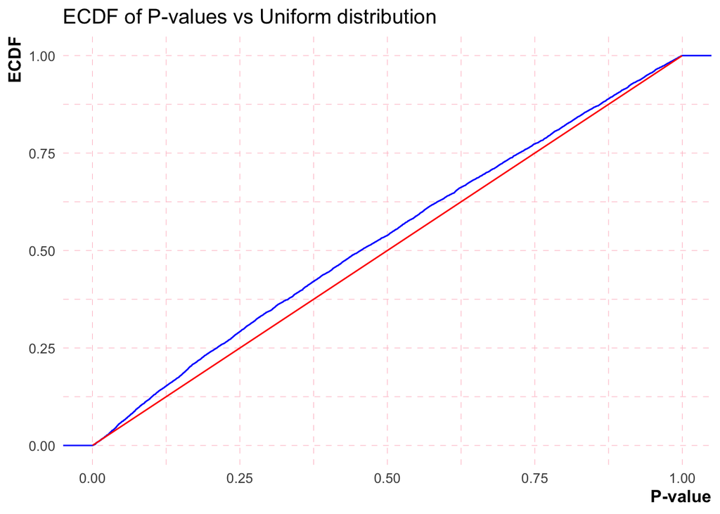

```r
ggplot(logistic, aes(x = P)) +
  stat_ecdf(geom = "step", color = "blue") +
  stat_function(fun = punif, color = "red") +
  labs(x = "P-value",
       y = "ECDF",
       title = "ECDF of P-values vs Uniform distribution") +
  my_theme()
```

If our p-values were uniformly distributed, we would expect the ECDF to closely follow the line of the uniform distribution (the red line), which is a straight diagonal line from (0,0) to (1,1). Any substantial deviation from this line suggests a departure from uniformity.

### 6.9 Kolmogorov-Smirnov test (K-S test)

The Kolmogorov-Smirnov test (K-S test) is a nonparametric test that can be used to compare a sample distribution with a theoretical distribution. In our case, we want to compare our distribution of p-values to a uniform distribution.

```r
# Generate some data
set.seed(123)
p_values <- linear$P

# Perform the K-S test
ks_test_result <- ks.test(p_values, "punif", 0, 1)
```

```
## Warning in ks.test.default(p_values, "punif", 0, 1): ties should not be present
## for the Kolmogorov-Smirnov test
```

```r
# Print the result
print(ks_test_result)
```

```
##
##  Asymptotic one-sample Kolmogorov-Smirnov test
##
## data:  p_values
## D = 0.011717, p-value = 0.1945
## alternative hypothesis: two-sided
```

### 6.10 Genomic inflation factor (lambda)

The genomic inflation factor (lambda) is a measure of test statistic inflation due to population stratification, cryptic relatedness, or other confounding variables in genome-wide association studies (GWAS). A lambda value close to 1 suggests that the population stratification or other confounding variables have little effect on the test statistics, while a value much greater than 1 suggests there may be confounding.

To calculate the genomic inflation factor (lambda), we would generally use the median chi-squared statistic from our GWAS and compare it to the expected median of a chi-squared distribution with one degree of freedom.

```r
# Calculate chi-square statistics
chi2_stats <- (linear$STAT)^2

# Calculate median of chi-square statistics
observed_median <- median(chi2_stats)

# Expected median of a chi-squared distribution with one degree of freedom
expected_median <- qchisq(0.5, df = 1)

# Calculate genomic inflation factor
lambda <- observed_median / expected_median
print(lambda)
```

```
## [1] 1.055488
```

A lambda value of 1.06 suggests that there is a small amount of inflation in our test statistics, which could be due to population stratification, cryptic relatedness, batch effects, or other uncontrolled confounding factors.